# DATA 606: Final Project

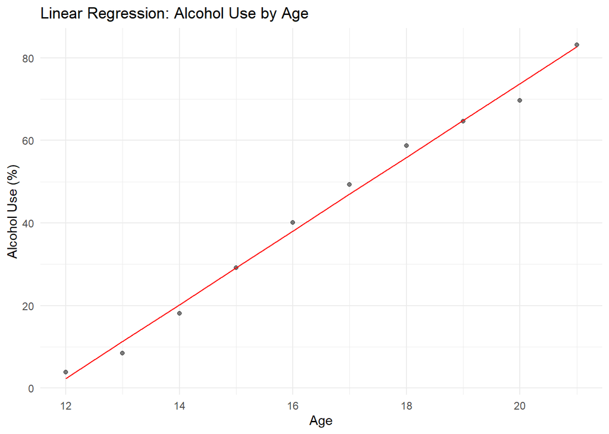

```r
plot_alcohol
```

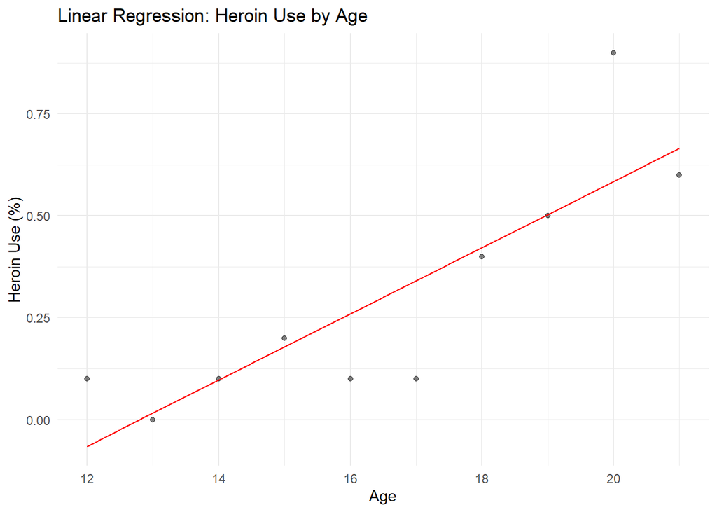

```r
plot_heroin
```

[figure not shown]

```r
plot_marijuana
```

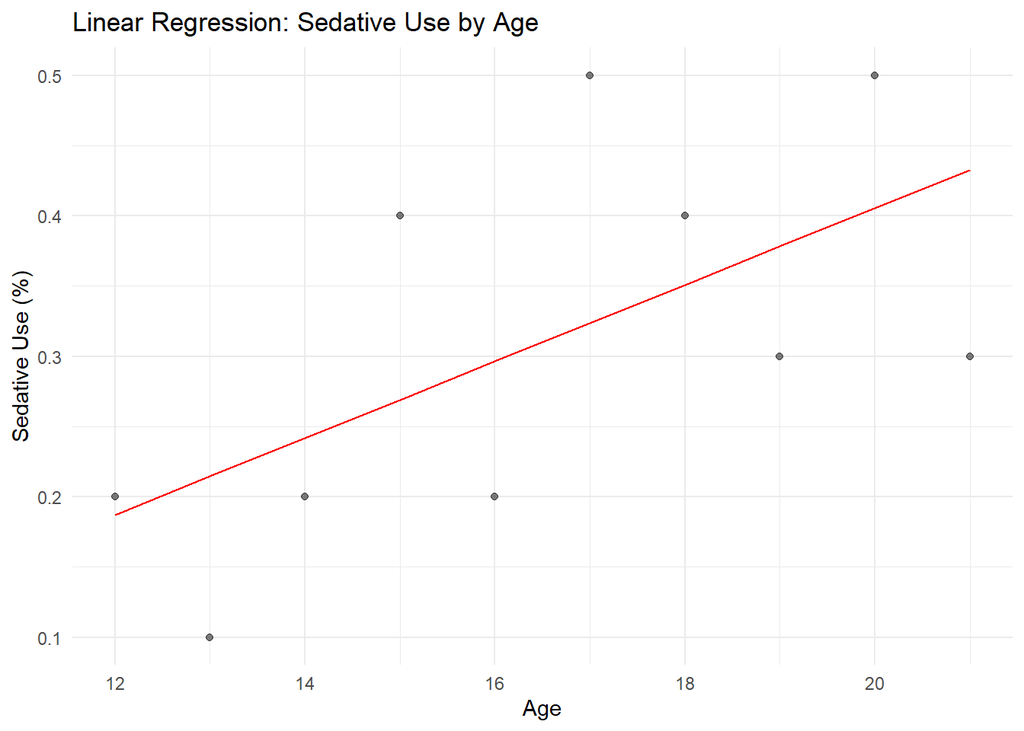

```r
plot_sedative
```

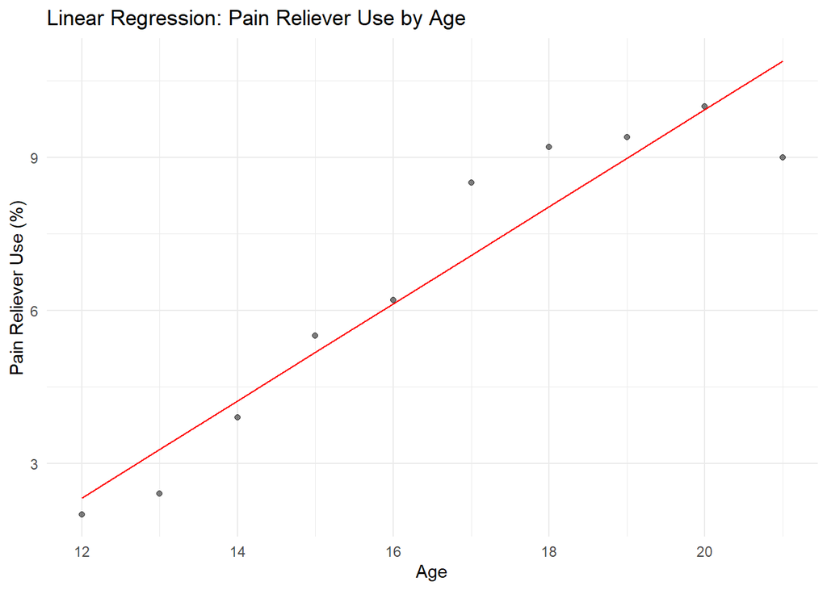

```r
plot_painreliever
```

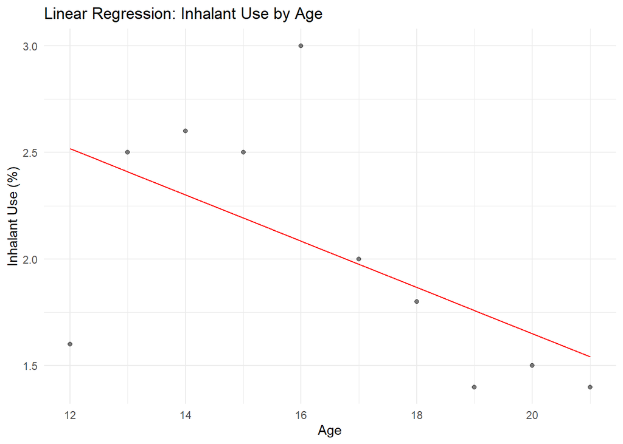

```r
plot_inhalant
```

```r
# Summarize each model
summary_crack <- summary(linear_model_crack)
summary_alcohol <- summary(linear_model_alcohol)
summary_heroin <- summary(linear_model_heroin)
summary_marijuana <- summary(linear_model_marijuana)

# Extract the relevant statistics
# For crack use
t_value_crack <- summary_crack$coefficients["age", "t value"]
p_value_crack <- summary_crack$coefficients["age", "Pr(>|t|)"]
conf_int_crack <- confint(linear_model_crack)["age", ]

# For alcohol use
t_value_alcohol <- summary_alcohol$coefficients["age", "t value"]
p_value_alcohol <- summary_alcohol$coefficients["age", "Pr(>|t|)"]
conf_int_alcohol <- confint(linear_model_alcohol)["age", ]

# For heroin use
t_value_heroin <- summary_heroin$coefficients["age", "t value"]
p_value_heroin <- summary_heroin$coefficients["age", "Pr(>|t|)"]
conf_int_heroin <- confint(linear_model_heroin)["age", ]

# For marijuana use
t_value_marijuana <- summary_marijuana$coefficients["age", "t value"]
p_value_marijuana <- summary_marijuana$coefficients["age", "Pr(>|t|)"]
conf_int_marijuana <- confint(linear_model_marijuana)["age", ]

# Output the results
list(
  crack_use = list(
    t_value = t_value_crack,
    p_value = p_value_crack,
    conf_int = conf_int_crack
  ),
  alcohol_use = list(
    t_value = t_value_alcohol,
    p_value = p_value_alcohol,
    conf_int = conf_int_alcohol
  ),
  heroin_use = list(
    t_value = t_value_heroin,
    p_value = p_value_heroin,
    conf_int = conf_int_heroin
  ),
  marijuana_use = list(
    t_value = t_value_marijuana,
    p_value = p_value_marijuana,
    conf_int = conf_int_marijuana
  )
)
```

```
## $crack_use
## $crack_use$t_value
## [1] 5.862946
##
## $crack_use$p_value
## [1] 0.000377206
##
## $crack_use$conf_int
##      2.5 %     97.5 %
## 0.04485767 0.10302111
##
##
## $alcohol_use
## $alcohol_use$t_value
## [1] 32.85144
##
## $alcohol_use$p_value
## [1] 8.039608e-10
##
## $alcohol_use$conf_int
##    2.5 %   97.5 %
## 8.296679 9.549382
##
##
## $heroin_use
## $heroin_use$t_value
## [1] 4.490429
##
## $heroin_use$p_value
## [1] 0.0020276
##
## $heroin_use$conf_int
##      2.5 %     97.5 %
## 0.03950664 0.12291760
##
##
## $marijuana_use
## $marijuana_use$t_value
## [1] 8.921706
##
## $marijuana_use$p_value
## [1] 1.975971e-05
##
## $marijuana_use$conf_int
##    2.5 %   97.5 %
## 3.091501 5.246681
```

### Data Analysis

Based on the linear regression models, it is evident that there was a linear relationship between age and the use of crack, heroin, and alcohol. For each of these substances, the models demonstrated significant trends with age as a predictor.

Crack Use

The linear regression model for crack use revealed a positive relationship between age and the percentage of users. This suggests that as age increases, the percentage of individuals using crack also tends to increase. The statistical significance of this relationship indicates that age is an important factor in understanding crack use patterns.

### Conclusion

To analyze the relationship between age and drug use, I created linear regression models for various substances, including cocaine, crack, alcohol, and heroin. Each model aimed to understand how drug use percentages change with age. The summary output for each model provided key metrics such as coefficients, R-squared value, p-value, and confidence intervals. These metrics helped us evaluate the significance and strength of the relationship between age and drug use. These findings highlight the importance of age-specific interventions and policies. Younger age groups might benefit from different preventive measures compared to older groups. Public health officials and policymakers can use this information to design targeted strategies to reduce drug use among specific age demographics. Tailored education and prevention programs can be more effective in addressing drug abuse.